# Dates and times

Author

Andrew Gard

```r
library(tidyverse)
theme_set(theme_minimal())

optical <- read_csv("optical.csv")
```

## Dates

Dates are best stored using the `Date` class, which `read_csv()` generally assigns when a set is imported. Consider `optical$dob`, for instance.

```r
glimpse(optical)
```

```
Rows: 43
Columns: 14
$ appt_date           <dttm> 2019-11-25 12:59:36, 2019-08-09 09:46:48, 2019-12…
$ patient_name        <chr> "Alan Green", "Jeremy Murphy", "Justin Gardner", "…
$ dob                 <date> 2000-02-17, 1927-11-15, 1936-07-15, 2013-10-10, 1…
$ age                 <dbl> 20, 92, 84, 6, 77, 74, 9, 89, 26, 56, 26, 17, 18, …
$ is_private          <dbl> 0, 0, 0, 0, 1, 1, 0, 1, 0, 0, 0, 0, 0, 1, 0, 1, 0,…
$ is_subsidised       <dbl> 0, 0, 0, 0, 1, 0, 1, 0, 0, 1, 0, 0, 0, 1, 1, 0, 1,…
$ is_smoker           <dbl> 0, 1, 1, 0, 1, 0, 0, 1, 1, 1, 0, 0, 1, 1, 1, 0, 1,…
$ is_driver           <dbl> 1, 0, 0, 0, 0, 1, 0, 0, 1, 0, 1, 0, 1, 1, 0, 0, 1,…
$ taking_medication   <chr> "no", "no", "no", "no", "yes", "no", "yes", "no", …
$ left_eye_value      <dbl> 1.797736, 4.545757, 2.613894, 4.741653, 4.687931, …
$ right_eye_value     <dbl> 2.485437, 5.165897, 5.380806, 5.070000, 4.097639, …
$ optician_first_name <chr> "Carl", "Janice", "Roger", "Raymond", "Norma", "Ma…
$ optician_last_name  <chr> "Larson", "Morris", "Nguyen", "Ruiz", "Green", "Si…
$ eye_difference      <dbl> -0.687701046, -0.620140076, -2.766912103, -0.32834…
```

Internally, dates are stored as integers representing the number of days since 1 January 1970, as you can check using `as.numeric()` or `unclass()`.

```r
unclass(optical$dob) |> head()
```

```
[1]  11004 -15388 -12223  15988  -9689  -8783
```

Dates can be subtracted to yield time differences, typically measured in days.

```r
diff(optical$dob)
```

```
Time differences in days
 [1] -26392   3165  28211 -25677    906  23725 -29060  22848 -10802  10832
[11]   3366   -487  -8736  -6524  16003   -516 -11543 -13493  21517 -11929
[21] -10925  -2236   1983  19248   6873 -14512  -2697  22306 -20380  18931
[31] -29863  20639 -23916  34466  -2565 -15793   8031     94   6345 -11028
[41] -11114   5493
```

## Parsing dates

Often, imported data sets include strings that look like dates but aren’t automatically stored that way. The `as.Date()` function isn’t a particularly user-friendly way forward, so we recommend the `tidyverse` function `lubridate::mdy()` and its friends `ymd()`, `ydm()`, `myd()`, `dmy()`, and `dym()`. These functions do an excellent job of parsing a wide variety of dating conventions, so long as the order of the components is consistent.

```r
text_dates <- c("Aug 3, 2026",
                "August 3 2026",
                "8/3/2026",
                "08-03-2026",
                "080326")

date_dates <- mdy(text_dates)
date_dates
```

```
[1] "2026-08-03" "2026-08-03" "2026-08-03" "2026-08-03" "2026-08-03"
```

```r
class(date_dates)
```

```
[1] "Date"
```

Dates are displayed in year-month-day format by default, which is ideal for sorting. If you need a different printing convention, use the `format()` function.

Dates can be built manually using `make_date()`, which is particularly useful when a dataset includes separate columns for `year`, `month`, and `day`.

```r
make_date(year = 2026,
          month = 8,
          day = 3)
```

```
[1] "2026-08-03"
```

## Extracting components

Functions to extract date components all have logical names.

```r
weekdays(optical$dob) # base R
```

```
 [1] "Thursday"  "Tuesday"   "Wednesday" "Thursday"  "Wednesday" "Saturday"
 [7] "Monday"    "Friday"    "Friday"    "Thursday"  "Sunday"    "Saturday"
[13] "Tuesday"   "Tuesday"   "Tuesday"   "Wednesday" "Friday"    "Friday"
[19] "Monday"    "Sunday"    "Saturday"  "Monday"    "Friday"    "Sunday"
[25] "Friday"    "Thursday"  "Wednesday" "Monday"    "Friday"    "Tuesday"
[31] "Friday"    "Thursday"  "Sunday"    "Wednesday" "Monday"    "Friday"
[37] "Thursday"  "Saturday"  "Tuesday"   "Friday"    "Tuesday"   "Thursday"
[43] "Tuesday"
```

```r
year(optical$dob) # lubridate
```

```
 [1] 2000 1927 1936 2013 1943 1945 2010 1931 1993 1964 1993 2003 2001 1977 1960
[16] 2003 2002 1970 1933 1992 1960 1930 1924 1929 1982 2001 1961 1953 2015 1959
[31] 2011 1929 1985 1920 2014 2007 1964 1986 1986 2004 1973 1943 1958
```

```r
month(optical$dob)
```

```
 [1]  2 11  7 10  6 12 11  5 11  4 12  3 11 12  2 11  6 11 12 11  3  4  2  8  4
[26]  2  5 12  1  4  2  5 11  5  9  9  6  6  9  1 11  6  7
```

```r
day(optical$dob)
```

```
 [1] 17 15 15 10 23 15 29  8 26 30 26 15 13 13  2 26 28 20 11  8 12 14 29  4 16
[26]  8 17 28 23  7  4  2  3 12 22 14 18 14 16 30 20 17  1
```

## Date-times

Moments in time are identified using the `dttm` class. In the `optical` dataset, `appt_date` has this class.

```r
glimpse(optical)
```

```
Rows: 43
Columns: 14
$ appt_date           <dttm> 2019-11-25 12:59:36, 2019-08-09 09:46:48, 2019-12…
$ patient_name        <chr> "Alan Green", "Jeremy Murphy", "Justin Gardner", "…
$ dob                 <date> 2000-02-17, 1927-11-15, 1936-07-15, 2013-10-10, 1…
$ age                 <dbl> 20, 92, 84, 6, 77, 74, 9, 89, 26, 56, 26, 17, 18, …
$ is_private          <dbl> 0, 0, 0, 0, 1, 1, 0, 1, 0, 0, 0, 0, 0, 1, 0, 1, 0,…
$ is_subsidised       <dbl> 0, 0, 0, 0, 1, 0, 1, 0, 0, 1, 0, 0, 0, 1, 1, 0, 1,…
$ is_smoker           <dbl> 0, 1, 1, 0, 1, 0, 0, 1, 1, 1, 0, 0, 1, 1, 1, 0, 1,…
$ is_driver           <dbl> 1, 0, 0, 0, 0, 1, 0, 0, 1, 0, 1, 0, 1, 1, 0, 0, 1,…
$ taking_medication   <chr> "no", "no", "no", "no", "yes", "no", "yes", "no", …
$ left_eye_value      <dbl> 1.797736, 4.545757, 2.613894, 4.741653, 4.687931, …
$ right_eye_value     <dbl> 2.485437, 5.165897, 5.380806, 5.070000, 4.097639, …
$ optician_first_name <chr> "Carl", "Janice", "Roger", "Raymond", "Norma", "Ma…
$ optician_last_name  <chr> "Larson", "Morris", "Nguyen", "Ruiz", "Green", "Si…
$ eye_difference      <dbl> -0.687701046, -0.620140076, -2.766912103, -0.32834…
```

Date-times are relative to location. To be truly unambiguous, a time zone must be included. In general, R will default to UTC (also called Greenwich mean time), though there are cases where your machine’s local time zone will be used instead.

The `tz()` function is used to extract or assign time zone information.

```r
tz(optical$appt_date)
```

```
[1] "UTC"
```

```r
tz(optical$appt_date) <- "America/Chicago"
```

Alternatively, you might want to convert times rather than just overwrite the location. Use `with_tz()` for this.

```r
optical$appt_date |> head()
```

```
[1] "2019-11-25 12:59:36 CST" "2019-08-09 09:46:48 CDT"
[3] "2019-12-16 03:21:40 CST" "2019-01-31 17:39:56 CST"
[5] "2019-06-22 05:20:16 CDT" "2019-10-10 08:01:34 CDT"
```

```r
with_tz(optical$appt_date, "UTC") |> head()
```

```
[1] "2019-11-25 18:59:36 UTC" "2019-08-09 14:46:48 UTC"
[3] "2019-12-16 09:21:40 UTC" "2019-01-31 23:39:56 UTC"
[5] "2019-06-22 10:20:16 UTC" "2019-10-10 13:01:34 UTC"
```

Use `OlsonNames()` to see a list of approximately 600 available zones, and `Sys.timezone()` to see which one your system is currently using. To see your machine’s local time, use `Sys.time()`.

## Visualization

`ggplot` formats date-times logically in all plots.

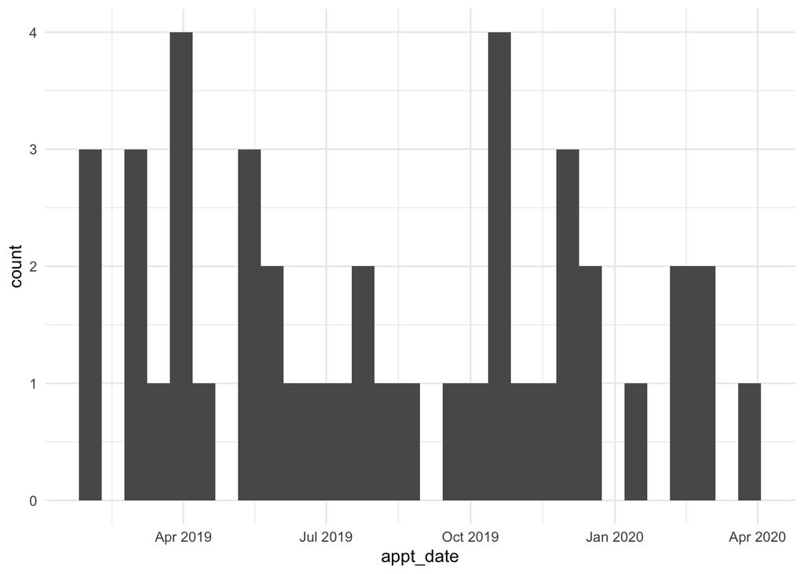

```r
ggplot(optical, aes(x = appt_date)) +
  geom_histogram()
```

If you need to change the format of the labels, use `scale_x_date`.